# Introduction to Unsupervised Learning

Unsupervised learning refers to a machine learning algorithm that infers information from a given dataset without any guidance. The algorithm relies on underlying similarities and patterns within the data to learn how the variables are related to one another. So in a way, we're "letting the data speak for itself."

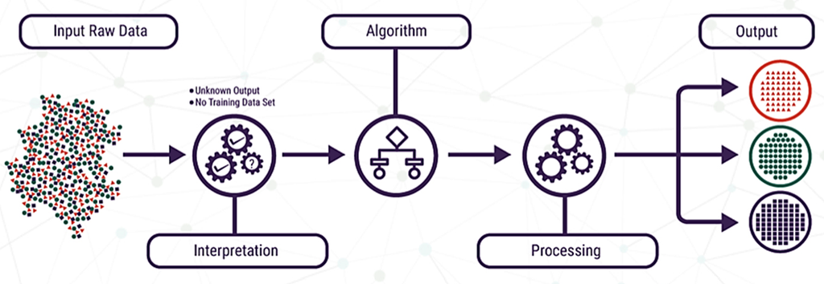

This is a great tool to use for initial exploration of a dataset without any defined hypothesis. Unsupervised learning is especially valuable in assessing a large dataset with multiple variables. For today's lecture, we'll be going over two broad applications of unsupervised learning: (1) clustering and (2) dimensionality reduction.

# Clustering - Identifying distinct groups based on similarity

We'll be covering two types of clustering techniques: hierarchical and k-means clustering. To introduce these methods, we'll consider the following planetary data:

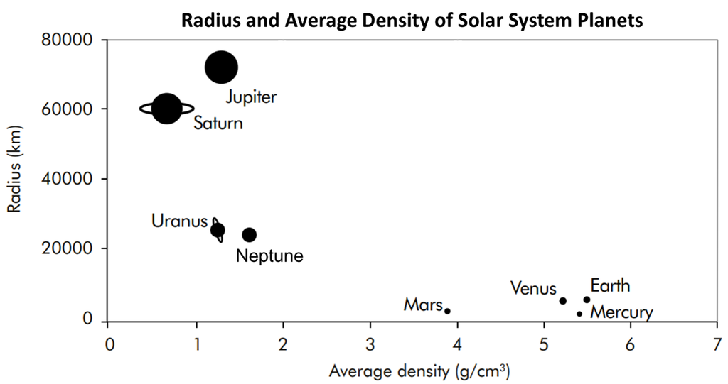

## Hierarchical Clustering

In hierarchical clustering, each observation starts in its own cluster at the base of the hierarchy. As we move up the hierarchy, observations that are most similar group together first until all observations are linked. This hierarchy of observations is often depicted as a dendrogram. In MATLAB, we can also plot a clustergram to visualize how similar the observations (e.g. planets) are based on different measurements (e.g. density, radius). The plot below shows an example of hierarchical clustering of planets in the solar system based on their average density and radius:

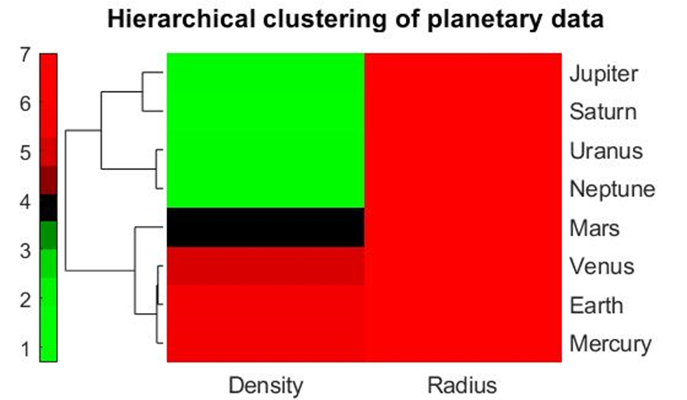

You may have noticed that the radius column doesn't show any differences between planets. This is because the range of values represented by the color gradient is limited to 1 through 7 (recall that planet radius was in the 10,000 range). To have a better visual sense in how a metric (e.g. radius) differs between observations (e.g. planets), we can standardize the values within a metric. Below is what the same clustergram of planetary data would look like with standardized density and radius:

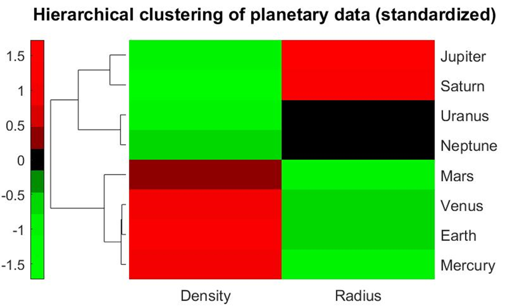

## Defining Similarity

One of the most common ways to apply unsupervised learning is to assess the similarity within a dataset. Similarity can be quantitatively described using a distance metric between two variables. There are various types of distance metrics that can be used, but we'll just go over two of the most common ones: Euclidean and correlation distance. The plot below shows how these distance metrics differ:

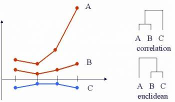

### Euclidean Distance

The Euclidean distance is broadly defined by the following formula:

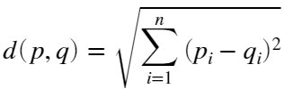

This is what the distance between p and q would look like when n = 2:

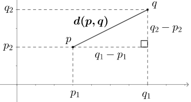

When analyzing biological data in MATLAB, we'll mostly be dealing with large vectors. In these cases, we let n be equal to the length of the vectors we're comparing (note: the vectors must have the same length).

For instance, let's say we're comparing vectors a and b as defined below:

```matlab
load('distance_data.mat')
a
```

a = 1×4

2.0000 1.5000 3.0000 7.0000

```matlab
b
```

b = 1×4

1.0000 0.5000 1.0000 1.5000

For this example, n = 4. We can calculate the Euclidean distance manually:

```matlab
d_euclid_man = sqrt(sum((a-b).^2))
```

d_euclid_man = 6.0208

We can also use the built-in function pdist:

```matlab
d_euclid_fun = pdist([a;b],'euclidean')
```

d_euclid_fun = 6.0208

Note that when using pdist, we combined vectors a and b into a matrix. This is because the pdist function is used to calculate the distance between all vectors in a matrix. If we had a matrix with three vectors, we would be calculating the distance for three pairwise combinations (C(3,2) = 3):

```matlab
c = [-1 -0.5 -0.5 -1];
d_euclid_3 = pdist([a;b;c])
```

d_euclid_3 = 1×3

6.0208 9.4472 3.6742

Note: Euclidean distance is the default metric for the pdist function.

### Correlation Distance

Going back to our example vectors a and b, the correlation distance can be calculated manually:

```matlab
d_corr_man = 1-corr(a',b')
```

d_corr_man = 0.1004

Or using the pdist function:

```matlab
d_corr_fun = pdist([a;b],'correlation')
```

d_corr_fun = 0.1004

Let's calculate the distances between vectors a, b, and c based on correlation:

```matlab
d_corr_3 = pdist([a;b;c],'correlation')
```

d_corr_3 = 1×3

0.1004 1.5205 1.7071

Note that the correlation distance can only range from 0 (similar) to 2 (dissimilar).

Additional information: refer to the pdist documentation for all available distance metrics.

## K-means Clustering

For k-means clustering, we specify how many distinct groups we think that the data will cluster into. K-means clustering then allocates data points to a cluster by minimizing the in-cluster sum of squares (more on this later). The value for k is typically chosen based on a priori information we may have on the data. Referring back to our planetary data:

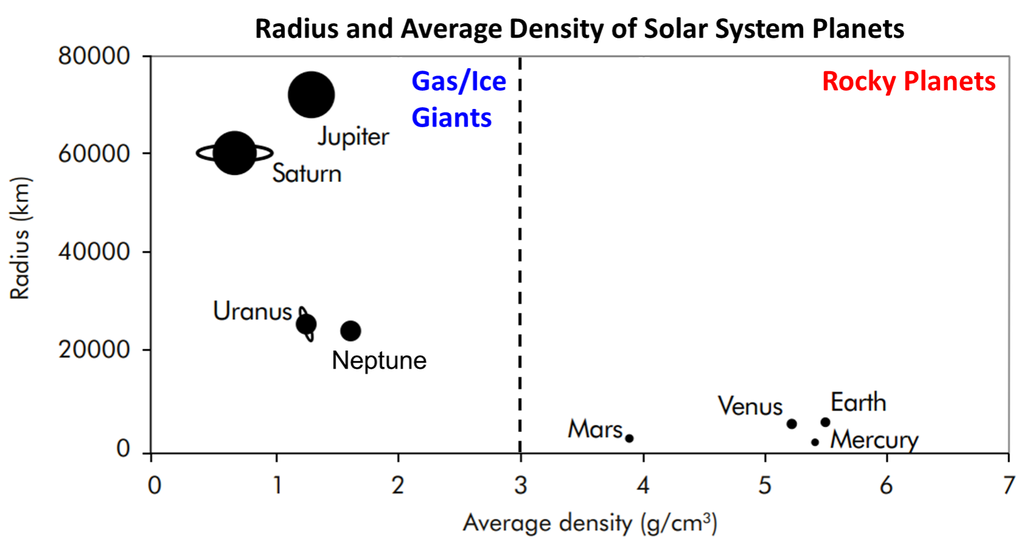

Based on this additional information, we could apply k-means clustering with k = 2 to group our planets:

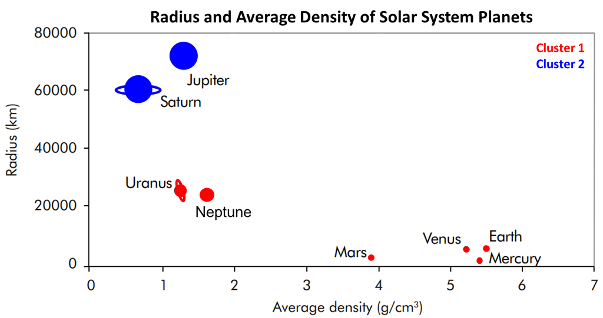

This is probably not how we expected the planets to cluster based on our reason to use k = 2. However, if we delve deeper into the information we were given before:

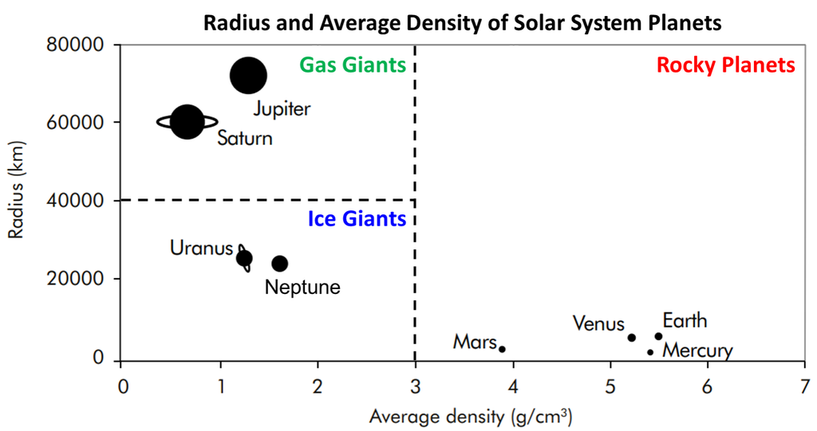

Let's see how the planets cluster based on k-means clustering with k = 3:

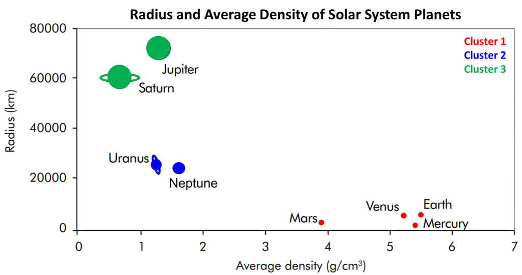

Now our results match what we expected based on our reason to use k = 3.

### Silhouette Analysis

You must be wondering: what if we don't have any prior knowledge of the data? What value do we use for k, and how do we know if this was a good choice? To consider these questions, we can conduct a silhouette analysis to determine which k value best minimizes the in-cluster sum of squares. For this analysis, we calculate the silhouette value for each observation and assess how they compare within a cluster by generating a silhouette plot. The silhouette value measures how similar an observation is to its own cluster compared to others based on a distance metric. This value ranges from -1 to 1, where a higher positive value implies that an observation is well-matched to its cluster and vice-versa.

One way to assess whether we chose a good value for k is to evaluate the mean of all silhouette values. For the purposes of this lesson, we'll refer to this mean value as the silhouette score. In general, a silhouette score above 0.5 indicates that the data is well separated. The following code calculates the silhouette score for our planetary data based on k-means clustering with different k values and visualizes the clustered data:

```matlab
% Load and view planetary data
load('planetary_data.mat')                     % load planetary data
disp(planet_table)                             % display data table
```

**Planet** **Density** **Radius** **_______** **_______** **______** Mercury 5.427 2439.5 Venus 5.243 6052 Earth 5.514 6378 Mars 3.933 3396 Jupiter 1.326 71492 Saturn 0.687 60268 Uranus 1.271 25559 Neptune 1.638 24764

```matlab
% Do k-means clustering and calculate silhouette score
X = [density radius];                          % array of planetary data
idx = kmeans(X,3);      % k-means clustering
s = silhouette(X,idx);                         % silhouette values
s_score = mean(s)                              % silhouette score
```

s_score = 0.9705

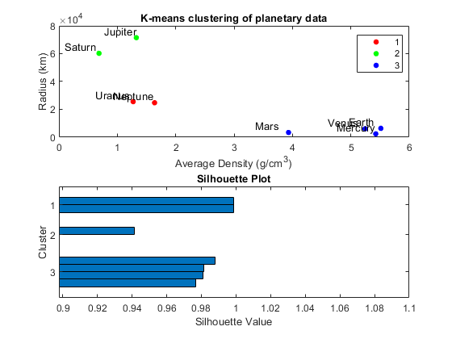

```matlab
% Plot of clustered data
subplot(2,1,1)
gscatter(density, radius, idx)
labelpoints(density, radius, planet)
xlabel('Average Density (g/cm^3)')
ylabel('Radius (km)')
title('K-means clustering of planetary data')

% Silhouette plot
subplot(2,1,2)
silhouette(X,idx)
title('Silhouette Plot')
```

Note: As the placement of cluster centroid is random for every iteration, clustering results may fluctuate for different iterations. The kmeans function contains additional properties that can be used to address this problem. For the purposes of this lesson, we'll use the kmeans function as is, but we'll keep in mind that our clustering results may differ between iterations.

### Hierarchical vs. K-means Clustering

Both hierarchical clustering and k-means clustering are unsupervised learning methods for grouping data based on similarity. The difference between these two clustering methods is that hierarchical clustering takes a "bottom-up" approach, whereas k-means clustering takes a "top-down" approach.

In MATLAB, we can perform hierarchical clustering using the clustergram function, and k-means clustering using the kmeans function. The silhouette function is used to calculate the silhouette value for each observation based on its cluster assignment from k-means clustering. This function also generates a silhouette plot.

# In-class practice: clustering of the Framingham data

## Applying hierarchical clustering based on health measurements

Let's say we want to know if individuals who suffered from a heart attack were similar across their health measurements (e.g. heartrate, BMI) using hierarchical clustering. We would also like to know if the health profile for this group was different from that of individuals who did not have a record of heart attack. The first step is to load the data and define the subset we're interested in:

```matlab
fram = readtable('frmgham2.xls');           % load the Framingham data
health_vars = {'HOSPMI',...                 % define health variables
    'TOTCHOL','SYSBP','DIABP','BMI',...     % (+ heart attack occurrence)
    'HEARTRTE','GLUCOSE','HDLC','LDLC'};
fram_health = fram(:,health_vars)           % create variable for data of interest
```

fram_health = 11627×9 table

|  | HOSPMI | TOTCHOL | SYSBP | DIABP | BMI | HEARTRTE | GLUCOSE | HDLC | LDLC |
| --- | --- | --- | --- | --- | --- | --- | --- | --- | --- |
| 1 | 1 | 195 | 106.0000 | 70.0000 | 26.9700 | 80 | 77 | NaN | NaN |
| 2 | 1 | 209 | 121.0000 | 66.0000 | NaN | 69 | 92 | 31 | 178 |
| 3 | 0 | 250 | 121.0000 | 81.0000 | 28.7300 | 95 | 76 | NaN | NaN |
| 4 | 0 | 260 | 105.0000 | 69.5000 | 29.4300 | 80 | 86 | NaN | NaN |
| 5 | 0 | 237 | 108.0000 | 66.0000 | 28.5000 | 80 | 71 | 54 | 141 |
| 6 | 0 | 245 | 127.5000 | 80.0000 | 25.3400 | 75 | 70 | NaN | NaN |
| 7 | 0 | 283 | 141.0000 | 89.0000 | 25.3400 | 75 | 87 | NaN | NaN |
| 8 | 0 | 225 | 150.0000 | 95.0000 | 28.5800 | 65 | 103 | NaN | NaN |
| 9 | 0 | 232 | 183.0000 | 109.0000 | 30.1800 | 60 | 89 | NaN | NaN |
| 10 | 0 | 285 | 130.0000 | 84.0000 | 23.1000 | 85 | 85 | NaN | NaN |
| 11 | 0 | 343 | 109.0000 | 77.0000 | 23.4800 | 90 | 72 | NaN | NaN |
| 12 | 0 | NaN | 155.0000 | 90.0000 | 24.6100 | 74 | NaN | NaN | NaN |
| 13 | 0 | 228 | 180.0000 | 110.0000 | 30.3000 | 77 | 99 | NaN | NaN |
| 14 | 0 | 230 | 177.0000 | 102.0000 | 31.3600 | 120 | 86 | NaN | NaN |
| 15 | 0 | 220 | 180.0000 | 106.0000 | 31.1700 | 86 | 81 | 46 | 135 |
| 16 | 0 | 205 | 138.0000 | 71.0000 | 33.1100 | 60 | 85 | NaN | NaN |
| 17 | 0 | 220 | 149.0000 | 81.0000 | 36.7600 | 80 | 98 | NaN | NaN |
| 18 | 0 | 313 | 100.0000 | 71.0000 | 21.6800 | 79 | 78 | NaN | NaN |
| 19 | 0 | NaN | 109.5000 | 72.5000 | 22.1900 | 75 | NaN | NaN | NaN |
| 20 | 0 | 320 | 110.0000 | 46.0000 | 22.0200 | 75 | 87 | 34 | 286 |
| 21 | 0 | 260 | 141.5000 | 89.0000 | 26.3600 | 76 | 79 | NaN | NaN |
| 22 | 0 | 292 | 132.0000 | 90.0000 | 25.3900 | 85 | 81 | NaN | NaN |
| 23 | 0 | 280 | 168.0000 | 100.0000 | 25.7200 | 92 | 82 | 44 | 236 |
| 24 | 0 | 225 | 162.0000 | 107.0000 | 23.6100 | 93 | 88 | NaN | NaN |
| 25 | 0 | 258 | 147.0000 | 102.0000 | 27.5000 | 75 | 74 | NaN | NaN |
| 26 | 0 | 211 | 173.0000 | 123.0000 | 29.1100 | 75 | 85 | 48 | 163 |
| 27 | 0 | 254 | 133.0000 | 76.0000 | 22.9100 | 75 | 76 | NaN | NaN |
| 28 | 0 | NaN | 127.5000 | 70.0000 | 20.3000 | 60 | 73 | NaN | NaN |
| 29 | 0 | 291 | 120.0000 | 70.0000 | 21.9800 | 62 | 83 | 60 | 217 |
| 30 | 0 | 247 | 131.0000 | 88.0000 | 27.6400 | 72 | 61 | NaN | NaN |

[output cut: 71 more lines]

We'll remove rows containing NaN values and get the subset for the first 50 entries. We'll also create a variable for the heart attack occurrence and a numerical array for the health measurement data:

```matlab
fram_health = rmmissing(fram_health);                   % remove rows containing NaN values
fram_health = fram_health(1:50,:)                       % subset of first 50 entries
```

fram_health = 50×9 table

|  | HOSPMI | TOTCHOL | SYSBP | DIABP | BMI | HEARTRTE | GLUCOSE | HDLC | LDLC |
| --- | --- | --- | --- | --- | --- | --- | --- | --- | --- |
| 1 | 0 | 237 | 108.0000 | 66 | 28.5000 | 80 | 71 | 54 | 141 |
| 2 | 0 | 220 | 180.0000 | 106 | 31.1700 | 86 | 81 | 46 | 135 |
| 3 | 0 | 320 | 110.0000 | 46 | 22.0200 | 75 | 87 | 34 | 286 |
| 4 | 0 | 280 | 168.0000 | 100 | 25.7200 | 92 | 82 | 44 | 236 |
| 5 | 0 | 211 | 173.0000 | 123 | 29.1100 | 75 | 85 | 48 | 163 |
| 6 | 0 | 291 | 120.0000 | 70 | 21.9800 | 62 | 83 | 60 | 217 |
| 7 | 0 | 159 | 124.0000 | 78 | 26.6200 | 68 | 135 | 53 | 106 |
| 8 | 0 | 264 | 141.0000 | 81 | 24.7700 | 85 | 97 | 58 | 206 |
| 9 | 0 | 215 | 144.5000 | 80 | 22.9600 | 57 | 91 | 62 | 135 |
| 10 | 0 | 212 | 163.0000 | 96 | 31.4500 | 82 | 84 | 40 | 172 |
| 11 | 0 | 162 | 152.5000 | 101 | 26.4300 | 105 | 78 | 31 | 91 |
| 12 | 0 | 226 | 126.0000 | 75 | 21.5900 | 85 | 102 | 84 | 142 |
| 13 | 1 | 283 | 159.0000 | 69.0000 | 32.9300 | 70 | 230 | 45 | 238 |
| 14 | 0 | 236 | 150.0000 | 89.0000 | 24.0100 | 90 | 80 | 93 | 143 |
| 15 | 0 | 290 | 132.0000 | 70.0000 | 22.7300 | 100 | 90 | 54 | 236 |
| 16 | 0 | 298 | 109.0000 | 60.0000 | 26.2000 | 80 | 100 | 38 | 260 |
| 17 | 0 | 240 | 131.0000 | 90.0000 | 26.7700 | 70 | 76 | 40 | 200 |
| 18 | 0 | 249 | 157.0000 | 87.0000 | 29.5500 | 65 | 73 | 78 | 171 |
| 19 | 0 | 300 | 125.0000 | 83.0000 | 34.3400 | 58 | 96 | 47 | 253 |
| 20 | 0 | 206 | 129.0000 | 85.0000 | 26.4000 | 84 | 69 | 47 | 159 |
| 21 | 1 | 320 | 148.0000 | 89.0000 | 22.7800 | 80 | 110 | 42 | 278 |
| 22 | 0 | 283 | 145.0000 | 85.0000 | 17.2800 | 88 | 80 | 65 | 218 |
| 23 | 0 | 226 | 190.0000 | 123.0000 | 45.4300 | 100 | 73 | 34 | 192 |
| 24 | 0 | 226 | 157.0000 | 95.0000 | 29.8600 | 88 | 99 | 61 | 165 |
| 25 | 0 | 246 | 202.0000 | 111.0000 | 26.6300 | 63 | 80 | 41 | 205 |
| 26 | 0 | 216 | 100.0000 | 75.0000 | 29.8200 | 70 | 68 | 30 | 186 |
| 27 | 0 | 293 | 127.0000 | 77.0000 | 25.6800 | 90 | 115 | 52 | 241 |
| 28 | 0 | 176 | 139.0000 | 72.0000 | 27.0000 | 74 | 77 | 26 | 150 |
| 29 | 0 | 206 | 112.0000 | 80.0000 | 21.9600 | 63 | 138 | 84 | 102 |
| 30 | 0 | 241 | 135.0000 | 70.0000 | 25.6800 | 90 | 93 | 41 | 200 |
| 31 | 1 | 230 | 142.0000 | 90.5000 | 24.3300 | 70 | 61 | 30 | 200 |
| 32 | 0 | 251 | 132.0000 | 77.0000 | 19.3000 | 82 | 76 | 53 | 197 |
| 33 | 0 | 224 | 125.0000 | 68.0000 | 27.3500 | 80 | 109 | 35 | 189 |
| 34 | 0 | 241 | 145.0000 | 85.0000 | 25.6600 | 96 | 102 | 68 | 173 |
| 35 | 1 | 216 | 117.0000 | 70.0000 | 21.3500 | 72 | 49 | 42 | 174 |
| 36 | 0 | 180 | 195.0000 | 107.0000 | 22.3600 | 68 | 75 | 60 | 120 |
| 37 | 0 | 229 | 145.0000 | 77.0000 | 23.0900 | 72 | 83 | 39 | 170 |
| 38 | 0 | 262 | 188.0000 | 104.0000 | 20.2600 | 61 | 82 | 54 | 185 |
| 39 | 0 | 276 | 148.0000 | 84.0000 | 19.6400 | 80 | 88 | 39 | 189 |
| 40 | 1 | 236 | 125.0000 | 74.0000 | 22.4900 | 90 | 103 | 30 | 206 |
| 41 | 0 | 246 | 153.0000 | 78.0000 | 25.3100 | 110 | 83 | 54 | 192 |
| 42 | 0 | 194 | 206.0000 | 106.0000 | 31.4500 | 120 | 178 | 59 | 121 |
| 43 | 0 | 238 | 113.0000 | 75.0000 | 23.3500 | 90 | 89 | 46 | 192 |
| 44 | 0 | 314 | 143.0000 | 66.0000 | 18.3200 | 93 | 96 | 61 | 237 |
| 45 | 0 | 272 | 116.0000 | 66.0000 | 23.1800 | 77 | 74 | 41 | 231 |
| 46 | 0 | 213 | 122.0000 | 77.0000 | 31.0600 | 60 | 83 | 56 | 157 |
| 47 | 0 | 208 | 122.0000 | 74.0000 | 40.3300 | 75 | 82 | 35 | 173 |
| 48 | 0 | 229 | 141.0000 | 91.0000 | 32.4900 | 96 | 96 | 62 | 167 |
| 49 | 0 | 229 | 120.0000 | 70.0000 | 23.2400 | 66 | 74 | 73 | 135 |
| 50 | 0 | 198 | 150.0000 | 82.0000 | 40.8000 | 60 | 81 | 56 | 89 |

```matlab
heart_attack = repmat({'No'},50,1);                     % heart attack occurrence (0 = No)
heart_attack(fram_health.HOSPMI == 1) = {'Yes'}         % heart attack occurrence (1 = Yes)
```

heart_attack = 50×1 cell array

'No'  
'No'  
'No'  
'No'  
'No'  
'No'  
'No'  
'No'  
'No'  
'No'

```matlab
fram_health_data = table2array(fram_health(:,2:end))    % numerical data array (- heart attack occurrence)
```

fram_health_data = 50×8

237.0000 108.0000 66.0000 28.5000 80.0000 71.0000 54.0000 141.0000 220.0000 180.0000 106.0000 31.1700 86.0000 81.0000 46.0000 135.0000 320.0000 110.0000 46.0000 22.0200 75.0000 87.0000 34.0000 286.0000 280.0000 168.0000 100.0000 25.7200 92.0000 82.0000 44.0000 236.0000 211.0000 173.0000 123.0000 29.1100 75.0000 85.0000 48.0000 163.0000 291.0000 120.0000 70.0000 21.9800 62.0000 83.0000 60.0000 217.0000 159.0000 124.0000 78.0000 26.6200 68.0000 135.0000 53.0000 106.0000 264.0000 141.0000 81.0000 24.7700 85.0000 97.0000 58.0000 206.0000 215.0000 144.5000 80.0000 22.9600 57.0000 91.0000 62.0000 135.0000 212.0000 163.0000 96.0000 31.4500 82.0000 84.0000 40.0000 172.0000

Now we can perform hierarchical clustering for this data subset. For this example, we'll use Euclidean distance (default) as our distance metric for assessing similarity. We'll also cluster along both rows and columns (default) and provide labels (rows = heart attack occurrence, columns = health measurements). Finally, we'll standardize each column to better compare measurements between patients:

```matlab
col_names = fram_health.Properties.VariableNames(2:end); % column names (- heart attack occurrence)
fram_health_cg = clustergram(fram_health_data,...        % clustergram with...
    'RowLabels',heart_attack,...                         % labeled rows (heart attack occurrence)
    'ColumnLabels',col_names,...                         % labeled columns (health measurements)
    'Standardize','column')                              % standardized columns
```

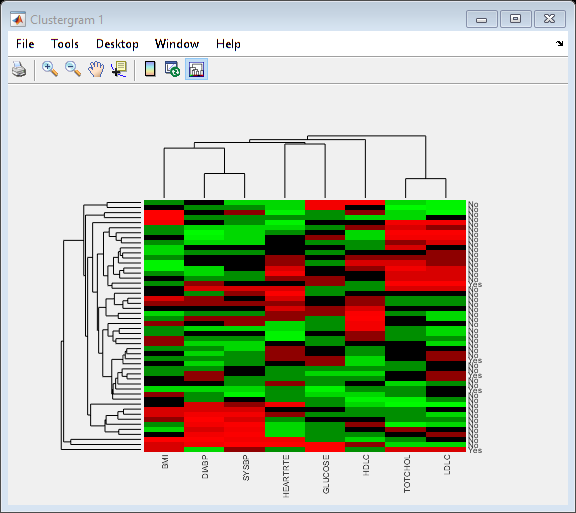

Clustergram object with 50 rows of nodes and 8 columns of nodes.

This clustergram shows how specific measurements compare between patient clusters, and which patients are most similar based on Euclidean distance.

Question: Did individuals who suffered from a heart attack cluster together?

Let's see how the clustergram changes if we use Pearson's correlation as our distance metric:

```matlab
fram_health_cg_corr = clustergram(fram_health_data,...  % clustergram with...
    'RowLabels',heart_attack,...                        % labeled rows (heart attack occurrence)
    'ColumnLabels',col_names,...                        % labeled columns (health measurements)
    'Standardize','column',...                          % standardized columns
    'RowPDist','correlation',...                        % correlation as distance metric (rows)
    'ColumnPDist','correlation')                        % correlation as distance metric (columns)
```

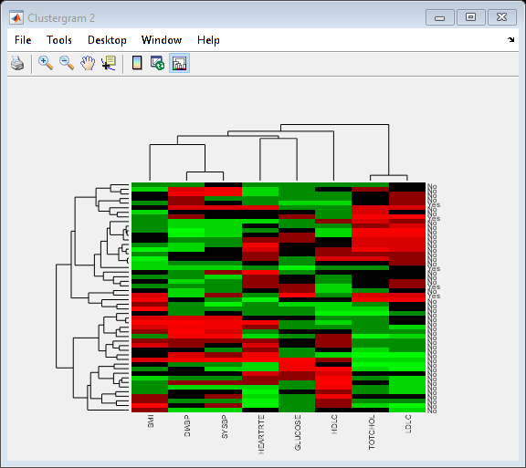

Clustergram object with 50 rows of nodes and 8 columns of nodes.

Question: How did the clustering change when using correlation as our distance metric? Did individuals who suffered from a heart attack cluster together?

## Applying k-means clustering for the Framingham data

```matlab
fram_kmeans = fram_health(:,{'HOSPMI','TOTCHOL','LDLC'}); % define dataset to use
```

```matlab
X = table2array(fram_kmeans);                   % numerical array of dataset
idx = kmeans(X,2);                              % k-means clustering (idx = cluster identity)
s = silhouette(X,idx);                          % vector for silhouette values
s_score = mean(s)                               % silhouette score
```

s_score = 0.6633

Let's visualize a scatter plot of our data clustered into 2 groups. We'll also look at the corresponding silhouette plot:

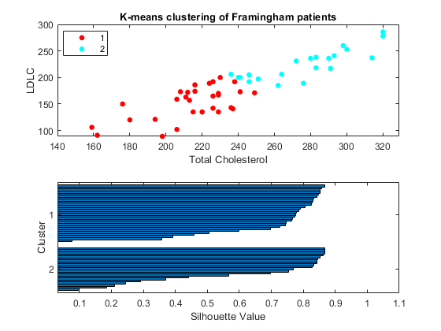

```matlab
subplot(2,1,1)
gscatter(fram_kmeans.TOTCHOL,fram_kmeans.LDLC,idx); % scatter plot with cluster annotation
xlabel('Total Cholesterol'); ylabel('LDLC')         % add axis labels
title('K-means clustering of Framingham patients')  % add title
subplot(2,1,2)
silhouette(X,idx)                                   % silhouette plot
```

Question: Does one of our clusters encompass individuals who have suffered from heart attack?

Activity: How can we modify the code above to apply k-means clustering for k = 3? How does the s_score value compare between k = 3 and k = 2?

# Dimensionality Reduction - Representing the variability in the dataset in lower dimensions

Biomedical data is often tremendously large and highly complex. Thus, it's hard to interpret this data when considering all the information available. By applying dimensionality reduction, we can transform the data into a lower-dimension representation that is much easier to interpret. In this lesson, we'll go over one type of dimensionality reduction method known as principal component analysis, or PCA.

## Principal Component Analysis

In PCA, an orthogonal linear transformation is applied to the data, projecting it onto a new coordinate system defined by principal components.

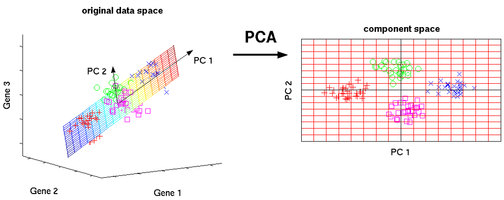

A principal component (PC) is a vector of weight (or coefficient) values assigned to each feature, or descriptive variable. Note that the number of features dictates the number of PCs that are determined. In the image below, P represents the matrix of principal components that is used to linearly transform the original data (X) into a new representative data (Y) that can be visualized in a component space:

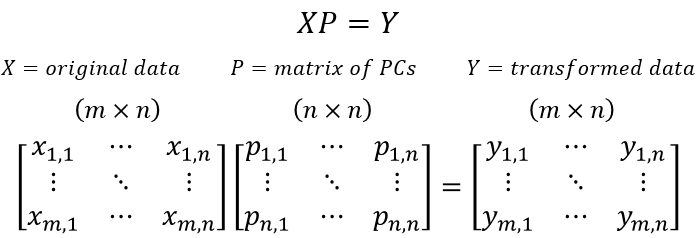

In PCA, P (matrix of PCs) is typically determined by (1) eigenvalue decomposition (EVD) of the data covariance matrix, or (2) singular vector decomposition (SVD) of the data. For this lesson, we'll not delve into the specifics of how EVD or SVD is applied (for more information, refer to [this link](https://builtin.com/data-science/step-step-explanation-principal-component-analysis) for EVD and [this link](https://towardsdatascience.com/svd-8c2f72e264f) for SVD).

Note: refer to the pca MATLAB documention for additional information on algorithms used for PCA.

### Why do PCA?

The main goal when conducting PCA is to determine a reduced representation of the original data that can be visualized. This is done by determining a ranked list of linearly independent principal components that altogether describe the variance within the data. This list of PCs is ranked by decreasing percentage of variance explained, where the first PC explains the most variance, or is best representative, of the data. The figure below shows an example of how much variance each PC explains for a dataset with 10 features:

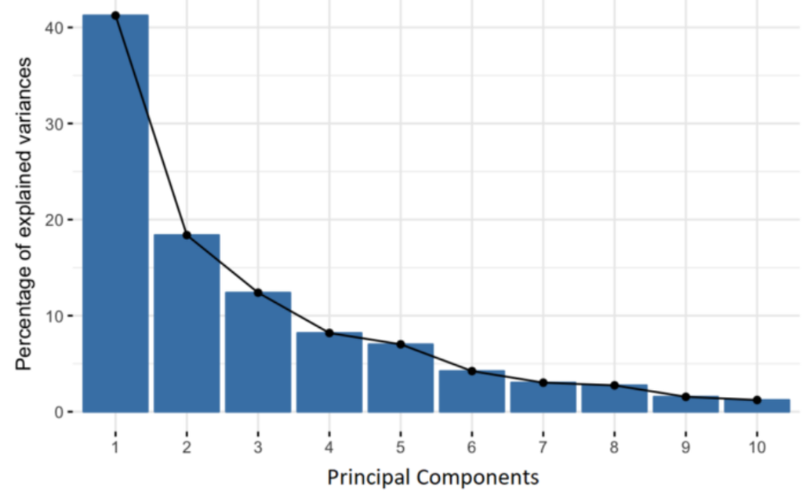

For the example shown above, we are able to represent ~60% of the variance using the first two PCs. In other words, if we were to plot the data based on PC1 and PC2, we would be visualizing a two-dimensional representation of the data that explains ~60% of the variance.

Note 1: PCs differ in the weights (or coefficients) associated with the features. If a PC (e.g. PC1) can describe most of the variance in the data (> 50%), then we can evaluate the coefficients in this PC to see which feature(s) are most important (have the greatest absolute weight). In other words, the coefficient values for a PC can tell us which features are most responsible for the patterns seen in our data.

Note 2: As the new representations of the observations in the principal component space are linear combinations of the original variables (features), it's important to normalize the data before conducting PCA. This ensures a unit variance for all variables, thus allowing comparable contributions from all variables when the data is transformed. In other words, normalizing the data reduces any bias there might be for a particular feature.

In MATLAB, the pca function is used to perform PCA based on SVD. The zscore function can be used to normalize the data before doing PCA.

### Example: applying PCA for the Framingham data

For this analysis, we'll consider the same dataset of health measurements we used for hierarchical clustering. Recall that this dataset contains 8 measurements, or features. This means that we'll be determining 8 linearly independent PCs by peforming PCA. Let's first normalize this data (X) then determine the matrix of principal components (P), the matrix of the transformed data (Y), and a vector for the variance explained by each PC (explained):

```matlab
% Normalize health data
X = zscore(fram_health_data);

% Do PCA (P = PC matrix, Y = transformed data, explained = variance explained)
[P, Y, ~, ~, explained] = pca(X)
```

P = 8×8

-0.4827 0.4007 0.1179 -0.1490 -0.2451 0.2669 -0.0702 -0.6588 0.4259 0.4640 0.1030 -0.2430 -0.2304 -0.2009 -0.6530 0.1175 0.4975 0.3172 -0.0428 -0.3250 -0.1760 -0.0057 0.7068 -0.1178 0.3080 0.1195 -0.4000 0.5095 -0.1870 0.6527 -0.1008 0.0050 0.0865 0.4261 0.2034 0.0669 0.8517 0.1980 0.0014 -0.0198 0.0080 0.2654 0.4218 0.7255 -0.2016 -0.3907 0.1753 -0.0350 0.0825 -0.2129 0.7552 -0.1307 -0.1855 0.5133 0.0226 0.2493 -0.4784 0.4603 -0.1553 -0.0743 -0.1426 0.0839 0.1666 0.6888

Y = 50×8

-0.5215 -1.6052 -0.2357 0.3907 0.6920 0.8169 -0.1963 -0.5006 2.3683 0.7278 -0.4408 -0.4640 0.0129 0.0919 -0.2252 -0.4228 -4.1205 0.4460 -0.7826 0.2102 -0.0142 -0.0804 -0.5994 0.0604 -0.0685 2.0982 -0.2426 -1.0340 0.0628 0.1511 0.1661 0.0046 2.4483 0.7653 -0.4888 -0.9148 -0.7875 -0.2474 0.9021 0.0229 -2.0656 -0.6547 0.3909 -0.5546 -1.0506 0.2614 0.0481 -0.1554 1.2830 -2.0055 0.5295 1.7387 -0.0868 -1.1953 0.3711 0.1954 -0.6344 0.4727 0.6382 -0.1334 0.0484 0.2724 0.0503 0.0698 0.4744 -1.6731 0.5839 -0.3279 -1.0722 -0.5973 -0.2519 -0.0224 1.4433 0.4967 -0.9619 0.0117 0.0200 -0.0256 -0.0905 0.1580

explained = 8×1

32.3024 19.2774 15.7793 12.9420 10.7258 6.7674 1.6609 0.5448

Question: How much variance is exlained by PC1 and PC2?

Now we'll visualize our transformed data in the component space by plotting PC1 vs. PC2. We'll also use our variable for heart attack occurrence to label our data:

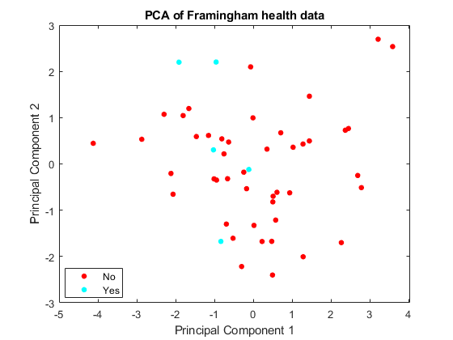

```matlab
% Visualize transformed data on PC1 vs. PC2 plot (label using heart attack occurrence)
figure
gscatter(Y(:,1), Y(:,2), heart_attack)
xlabel('Principal Component 1')
ylabel('Principal Component 2')
title('PCA of Framingham health data')
```

Based on this plot, we can see that individuals who suffered from a heart attack cluster within the negative range along PC1. We can check the PC matrix (P) to see which features contribute the most for PC1:

```matlab
% Assess coefficient values for PC1
feature = col_names';   % feature names (health measurements)
PC1 = P(:,1);           % coefficient values for PC1
table(feature, PC1)     % table of features matched to coefficient values
```

ans = 8×2 table

[output not shown]

# Unsupervised vs. Supervised Learning

All of the methods discussed in this lesson serve as applications for unsupervised learning. In machine learning, we can also process data using supervised learning, where information on the output data (e.g. labels) is considered during the learning process. While unsupervised learing is used for data exploration, supervised learning is typically used to train and develop predictive or classification tools based on labeled data.

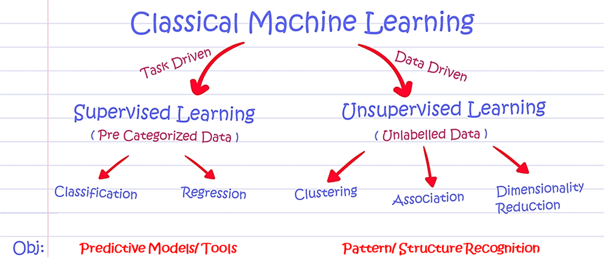

# Summary

- Unsupervised learning allows us to infer information about a dataset without any user guidance based on underlying similarities and patterns
- Common applications of unsupervised learning to analyze biomedical data include clustering (hierarchical, k-means) and dimensionality reduction (principal component analysis)
- Hierarchical clustering involves a "bottom-up" approach, whereas k-means clustering applies a "top-down" approach, to assign data into groups
- Principal component analysis (PCA) allows us to transform highly complex data into lower-dimension representations that are easier to interpret
- In contrast to unsupervised learning, supervised learning includes information on the output variables (e.g. labels) that can be used to train and develop predictive or classification tools

### Built-in MATLAB functions covered in this lesson:

- pdist: quantifies similarity using a distance metric (e.g. Euclidean, correlation)
- clustergram: performs hierarchical clustering
- kmeans: performs k-means clustering
- silhouette: calculates silhouette values and generates a silhouette plot for k-means clustering
- pca: performs principal component analysis (PCA)
- zscore: normalizes each column in a matrix to have mean 0 and standard deviation of 1

### References for additional information:

- [Eigenvalue Decomposition (EVD)](https://builtin.com/data-science/step-step-explanation-principal-component-analysis)
- [Singular Vector Decomposition (SVD)](https://towardsdatascience.com/svd-8c2f72e264f)